# Project Supervised Learning.

```python
import pandas as pd
import numpy as np
import matplotlib.pyplot as plt
%matplotlib inline
import seaborn as sns
from sklearn.model_selection import train_test_split
from sklearn.neighbors import KNeighborsClassifier
import warnings
warnings.filterwarnings('ignore')
from sklearn.linear_model import LogisticRegression
from sklearn.metrics import accuracy_score, confusion_matrix
```

```python
datan = pd.read_csv('Part1 - Normal.csv') #datan is the Normal data
datah = pd.read_csv('Part1 - Type_H.csv') #datah is the H type data
datas = pd.read_csv('Part1 - Type_S.csv') #datas is the S type data
```

### Checking the three datas one by one for any irregularities

```python
datan.head()
```

|  | P_incidence | P_tilt | L_angle | S_slope | P_radius | S_Degree | Class |
| --- | --- | --- | --- | --- | --- | --- | --- |
| 0 | 38.505273 | 16.964297 | 35.112814 | 21.540976 | 127.632875 | 7.986683 | Normal |
| 1 | 54.920858 | 18.968430 | 51.601455 | 35.952428 | 125.846646 | 2.001642 | Normal |
| 2 | 44.362490 | 8.945435 | 46.902096 | 35.417055 | 129.220682 | 4.994195 | Normal |
| 3 | 48.318931 | 17.452121 | 48.000000 | 30.866809 | 128.980308 | -0.910941 | Normal |
| 4 | 45.701789 | 10.659859 | 42.577846 | 35.041929 | 130.178314 | -3.388910 | Normal |

```python
datan.shape
```

```
(100, 7)
```

```python
datan.describe().transpose()
```

|  | count | mean | std | min | 25% | 50% | 75% | max |
| --- | --- | --- | --- | --- | --- | --- | --- | --- |
| P_incidence | 100.0 | 51.685244 | 12.368161 | 30.741938 | 42.817849 | 50.123115 | 61.470097 | 89.834676 |
| P_tilt | 100.0 | 12.821414 | 6.778503 | -5.845994 | 8.799951 | 13.482435 | 16.785953 | 29.894119 |
| L_angle | 100.0 | 43.542605 | 12.361388 | 19.071075 | 35.000000 | 42.638923 | 51.602346 | 90.563461 |
| S_slope | 100.0 | 38.863830 | 9.624004 | 17.386972 | 32.340487 | 37.059694 | 44.608788 | 67.195460 |
| P_radius | 100.0 | 123.890834 | 9.014246 | 100.501192 | 118.182659 | 123.874328 | 129.040401 | 147.894637 |
| S_Degree | 100.0 | 2.186572 | 6.307483 | -11.058179 | -1.511360 | 1.152710 | 4.968807 | 31.172767 |

```python
datan.isnull().count()
```

```
P_incidence    100
P_tilt         100
L_angle        100
S_slope        100
P_radius       100
S_Degree       100
Class          100
dtype: int64
```

#### We dont have any missing values.

```python
datan.dtypes
```

```
P_incidence    float64
P_tilt         float64
L_angle        float64
S_slope        float64
P_radius       float64
S_Degree       float64
Class           object
dtype: object
```

#### All the data types seem to be of the desired data types, We can assume there are no symbols or missing values. Hence no need to asssign data types, or fill the missing values.

```python
datah.head()
```

|  | P_incidence | P_tilt | L_angle | S_slope | P_radius | S_Degree | Class |
| --- | --- | --- | --- | --- | --- | --- | --- |
| 0 | 63.027818 | 22.552586 | 39.609117 | 40.475232 | 98.672917 | -0.254400 | Type_H |
| 1 | 39.056951 | 10.060991 | 25.015378 | 28.995960 | 114.405425 | 4.564259 | Type_H |
| 2 | 68.832021 | 22.218482 | 50.092194 | 46.613539 | 105.985135 | -3.530317 | Type_H |
| 3 | 69.297008 | 24.652878 | 44.311238 | 44.644130 | 101.868495 | 11.211523 | Type_H |
| 4 | 49.712859 | 9.652075 | 28.317406 | 40.060784 | 108.168725 | 7.918501 | Type_H |

```python
datah.shape
```

```
(60, 7)
```

```python
datah.describe().transpose()
```

|  | count | mean | std | min | 25% | 50% | 75% | max |
| --- | --- | --- | --- | --- | --- | --- | --- | --- |
| P_incidence | 60.0 | 47.638407 | 10.697131 | 26.147921 | 41.018099 | 46.416169 | 53.922329 | 74.433593 |
| P_tilt | 60.0 | 17.398795 | 7.016708 | 3.144669 | 12.874329 | 16.949285 | 22.002980 | 41.557331 |
| L_angle | 60.0 | 35.463524 | 9.767795 | 14.000000 | 29.038069 | 35.164873 | 42.011563 | 62.275275 |
| S_slope | 60.0 | 30.239612 | 7.555388 | 13.366931 | 25.215275 | 30.000659 | 34.962103 | 46.613539 |
| P_radius | 60.0 | 116.474968 | 9.355720 | 84.241415 | 112.280320 | 116.696146 | 122.042999 | 137.540613 |
| S_Degree | 60.0 | 2.480251 | 5.531177 | -10.675871 | -0.910819 | 2.542441 | 6.059666 | 15.779697 |

```python
datah.isnull().count()
```

```
P_incidence    60
P_tilt         60
L_angle        60
S_slope        60
P_radius       60
S_Degree       60
Class          60
dtype: int64
```

#### We dont have any missing values.

```python
datah.dtypes
```

```
P_incidence    float64
P_tilt         float64
L_angle        float64
S_slope        float64
P_radius       float64
S_Degree       float64
Class           object
dtype: object
```

#### All the data types seem to be of the desired data types, We can assume there are no symbols or missing values. Hence no need to asssign data types, or fill the missing values.

```python
datas.head()
```

|  | P_incidence | P_tilt | L_angle | S_slope | P_radius | S_Degree | Class |
| --- | --- | --- | --- | --- | --- | --- | --- |
| 0 | 74.377678 | 32.053104 | 78.772013 | 42.324573 | 143.560690 | 56.125906 | Type_S |
| 1 | 89.680567 | 32.704435 | 83.130732 | 56.976132 | 129.955476 | 92.027277 | Type_S |
| 2 | 44.529051 | 9.433234 | 52.000000 | 35.095817 | 134.711772 | 29.106575 | Type_S |
| 3 | 77.690577 | 21.380645 | 64.429442 | 56.309932 | 114.818751 | 26.931841 | Type_S |
| 4 | 76.147212 | 21.936186 | 82.961502 | 54.211027 | 123.932010 | 10.431972 | Type_S |

```python
datas.shape
```

```
(150, 7)
```

```python
datas.describe().transpose()
```

|  | count | mean | std | min | 25% | 50% | 75% | max |
| --- | --- | --- | --- | --- | --- | --- | --- | --- |
| P_incidence | 150.0 | 71.514224 | 15.109337 | 37.903910 | 60.658136 | 72.149306 | 81.075893 | 129.834041 |
| P_tilt | 150.0 | 20.748038 | 11.506169 | -6.554948 | 13.461149 | 19.309548 | 29.229680 | 49.431864 |
| L_angle | 150.0 | 64.110108 | 16.397068 | 24.710274 | 52.000000 | 62.555200 | 76.990924 | 125.742385 |
| S_slope | 150.0 | 50.766186 | 12.318813 | 19.290046 | 43.166815 | 50.751695 | 56.675435 | 121.429566 |
| P_radius | 150.0 | 114.518810 | 15.579995 | 70.082575 | 104.706761 | 114.842400 | 123.337307 | 163.071041 |
| S_Degree | 150.0 | 51.896687 | 40.108030 | 1.010041 | 30.393271 | 42.372509 | 61.894425 | 418.543082 |

```python
datas.isnull().count()
```

```
P_incidence    150
P_tilt         150
L_angle        150
S_slope        150
P_radius       150
S_Degree       150
Class          150
dtype: int64
```

#### We dont have any missing values.

```python
datas.dtypes
```

```
P_incidence    float64
P_tilt         float64
L_angle        float64
S_slope        float64
P_radius       float64
S_Degree       float64
Class           object
dtype: object
```

#### All the data types seem to be of the desired data types, We can assume there are no symbols or missing values. Hence no need to asssign data types, or fill the missing values.

### We can see that the three csv files that we have don't have any missing data, or symbols; and follows appropriate data type. So we can move further and append them into one.

```python
df = datan.append([datah,datas])
df.head()
```

|  | P_incidence | P_tilt | L_angle | S_slope | P_radius | S_Degree | Class |
| --- | --- | --- | --- | --- | --- | --- | --- |
| 0 | 38.505273 | 16.964297 | 35.112814 | 21.540976 | 127.632875 | 7.986683 | Normal |
| 1 | 54.920858 | 18.968430 | 51.601455 | 35.952428 | 125.846646 | 2.001642 | Normal |
| 2 | 44.362490 | 8.945435 | 46.902096 | 35.417055 | 129.220682 | 4.994195 | Normal |
| 3 | 48.318931 | 17.452121 | 48.000000 | 30.866809 | 128.980308 | -0.910941 | Normal |
| 4 | 45.701789 | 10.659859 | 42.577846 | 35.041929 | 130.178314 | -3.388910 | Normal |

```python
df.shape
```

```
(310, 7)
```

```python
df.describe().transpose()
```

|  | count | mean | std | min | 25% | 50% | 75% | max |
| --- | --- | --- | --- | --- | --- | --- | --- | --- |
| P_incidence | 310.0 | 60.496653 | 17.236520 | 26.147921 | 46.430294 | 58.691038 | 72.877696 | 129.834041 |
| P_tilt | 310.0 | 17.542822 | 10.008330 | -6.554948 | 10.667069 | 16.357689 | 22.120395 | 49.431864 |
| L_angle | 310.0 | 51.930930 | 18.554064 | 14.000000 | 37.000000 | 49.562398 | 63.000000 | 125.742385 |
| S_slope | 310.0 | 42.953831 | 13.423102 | 13.366931 | 33.347122 | 42.404912 | 52.695888 | 121.429566 |
| P_radius | 310.0 | 117.920655 | 13.317377 | 70.082575 | 110.709196 | 118.268178 | 125.467674 | 163.071041 |
| S_Degree | 310.0 | 26.296694 | 37.559027 | -11.058179 | 1.603727 | 11.767934 | 41.287352 | 418.543082 |

```python
df.Class.value_counts()
```

```
Type_S    133
Normal     73
Type_H     37
Nrmal      27
type_h     23
tp_s       17
Name: Class, dtype: int64
```

#### We can see that the Class column has different values which can and should be clubbed together.

```python
df.loc[df['Class']=='tp_s','Class']='Type_S'
df.loc[df['Class']=='Nrmal','Class']='Normal'
df.loc[df['Class']=='type_h','Class']='Type_H'
```

# Univariate Analysis

##### P_incidence - Mean is greater than median, we can see right skewed curve.

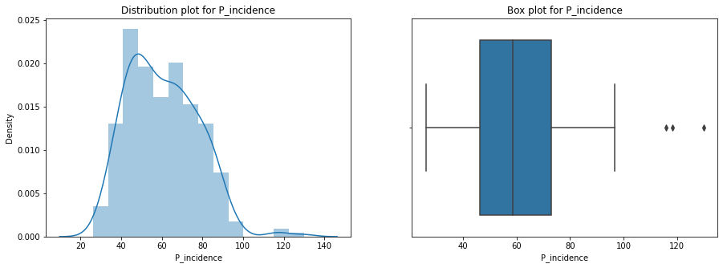

```
 Total Number of outliers in P_incidence: 3
```

```python
fig, axes = plt.subplots(1, 2, figsize=(15,5))
sns.boxplot(x = 'P_incidence', data=df , ax=axes[1])
sns.distplot(df['P_incidence'],  ax=axes[0])
axes[0].set_title('Distribution plot for P_incidence')
axes[1].set_title('Box plot for P_incidence')
plt.show()


q25= np.percentile(df['P_incidence'],25)
q75= np.percentile(df['P_incidence'],75)
iqr= q75-q25
threshold= iqr*1.5
lower = q25-threshold
upper = q75+threshold
outliers = [i for i in df['P_incidence'] if i < lower or i > upper]
print ('{} Total Number of outliers in P_incidence: {}'.format('\033[1m',len(outliers)))
```

#### We can see a normal distribution, with a few minor irregularities, and 3 visible outliers in Boxplot

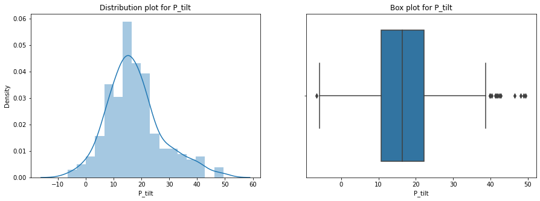

```
 Total Number of outliers in P_tilt: 13
```

```python
fig, axes = plt.subplots(1, 2, figsize=(15,5))
sns.boxplot(x = 'P_tilt', data=df , ax=axes[1])
sns.distplot(df['P_tilt'],  ax=axes[0])
axes[0].set_title('Distribution plot for P_tilt')
axes[1].set_title('Box plot for P_tilt')
plt.show()

q25= np.percentile(df['P_tilt'],25)
q75= np.percentile(df['P_tilt'],75)
iqr= q75-q25
threshold= iqr*1.5
lower = q25-threshold
upper = q75+threshold
outliers = [i for i in df['P_tilt'] if i < lower or i > upper]
print ('{} Total Number of outliers in P_tilt: {}'.format('\033[1m',len(outliers)))
```

#### We can see slightly right skewed distribution , with a few minor irregularities, and 13 outliers in Boxplot

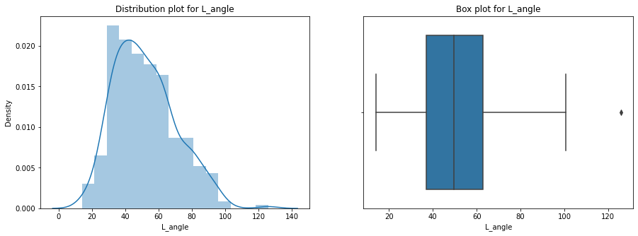

```
 Total Number of outliers in L_angle: 1
```

```python
fig, axes = plt.subplots(1, 2, figsize=(15,5))
sns.boxplot(x = 'L_angle', data=df , ax=axes[1])
sns.distplot(df['L_angle'],  ax=axes[0])
axes[0].set_title('Distribution plot for L_angle')
axes[1].set_title('Box plot for L_angle')
plt.show()

q25= np.percentile(df['L_angle'],25)
q75= np.percentile(df['L_angle'],75)
iqr= q75-q25
threshold= iqr*1.5
lower = q25-threshold
upper = q75+threshold
outliers = [i for i in df['L_angle'] if i < lower or i > upper]
print ('{} Total Number of outliers in L_angle: {}'.format('\033[1m',len(outliers)))
```

#### We can see a normal disttibution, with just one outlier.

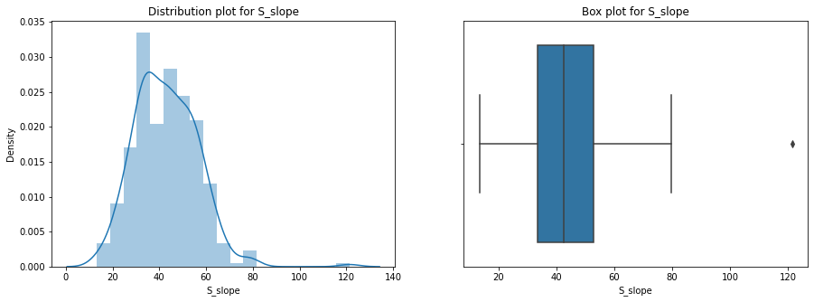

```
 Total Number of outliers in S_slope: 1
```

```python
fig, axes = plt.subplots(1, 2, figsize=(15,5))
sns.boxplot(x = 'S_slope', data=df , ax=axes[1])
sns.distplot(df['S_slope'],  ax=axes[0])
axes[0].set_title('Distribution plot for S_slope')
axes[1].set_title('Box plot for S_slope')
plt.show()

q25= np.percentile(df['S_slope'],25)
q75= np.percentile(df['S_slope'],75)
iqr= q75-q25
threshold= iqr*1.5
lower = q25-threshold
upper = q75+threshold
outliers = [i for i in df['S_slope'] if i < lower or i > upper]
print ('{} Total Number of outliers in S_slope: {}'.format('\033[1m',len(outliers)))
```

#### We can see normal distribution, with 1 outlier.

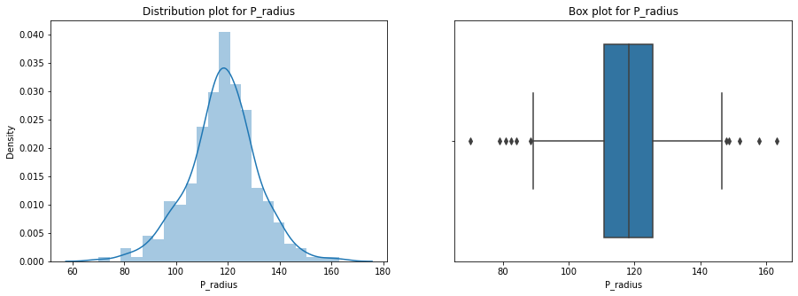

```
 Total Number of outliers in P_radius: 11
```

```python
fig, axes = plt.subplots(1, 2, figsize=(15,5))
sns.boxplot(x = 'P_radius', data=df , ax=axes[1])
sns.distplot(df['P_radius'],  ax=axes[0])
axes[0].set_title('Distribution plot for P_radius')
axes[1].set_title('Box plot for P_radius')
plt.show()

q25= np.percentile(df['P_radius'],25)
q75= np.percentile(df['P_radius'],75)
iqr= q75-q25
threshold= iqr*1.5
lower = q25-threshold
upper = q75+threshold
outliers = [i for i in df['P_radius'] if i < lower or i > upper]
print ('{} Total Number of outliers in P_radius: {}'.format('\033[1m',len(outliers)))
```

#### We can see a normal distribution, with 11 total outliers, spread on both ends.

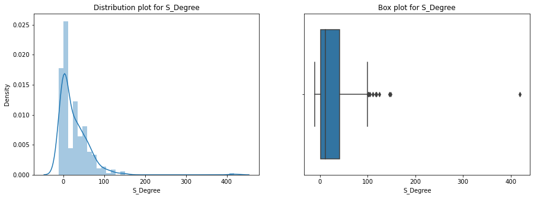

```
 Total Number of outliers in S_Degree: 10
```

```python
fig, axes = plt.subplots(1, 2, figsize=(15,5))
sns.boxplot(x = 'S_Degree', data=df , ax=axes[1])
sns.distplot(df['S_Degree'],  ax=axes[0])
axes[0].set_title('Distribution plot for S_Degree')
axes[1].set_title('Box plot for S_Degree')
plt.show()

q25= np.percentile(df['S_Degree'],25)
q75= np.percentile(df['S_Degree'],75)
iqr= q75-q25
threshold= iqr*1.5
lower = q25-threshold
upper = q75+threshold
outliers = [i for i in df['S_Degree'] if i < lower or i > upper]
print ('{} Total Number of outliers in S_Degree: {}'.format('\033[1m',len(outliers)))
```

#### As seen in the 5 point summary, the data is right skewed; with 10 outliers. 1 Outlier found far from the upper limit.

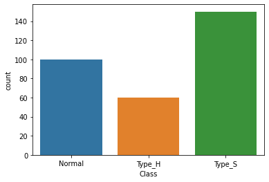

```python
cnt = sns.countplot(df['Class'])
```

#### We can see that Type_S has the most value counts, followed by Normal, and Type_H.

## Lets see co-relation of each feature with Class feature with

# Bivariate Analysis

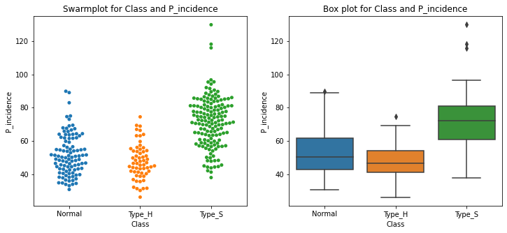

```python
fig, axes = plt.subplots(1, 2, figsize=(12,5))
sns.swarmplot (df ['Class'], df ['P_incidence'], ax=axes[0]);
sns.boxplot(df['Class'], df['P_incidence'], ax=axes[1])
axes[0].set_title('Swarmplot for Class and P_incidence')
axes[1].set_title('Box plot for Class and P_incidence')
```

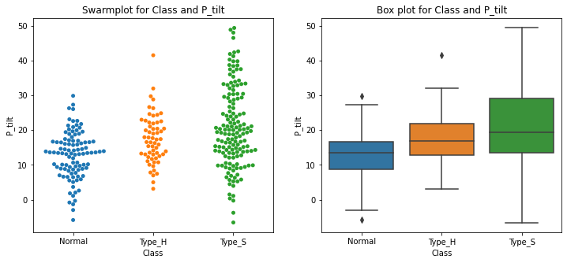

```python
fig, axes = plt.subplots(1, 2, figsize=(12,5))
sns.swarmplot (df ['Class'], df ['P_tilt'], ax=axes[0]);
sns.boxplot(df['Class'], df['P_tilt'], ax=axes[1])
axes[0].set_title('Swarmplot for Class and P_tilt')
axes[1].set_title('Box plot for Class and P_tilt')
```

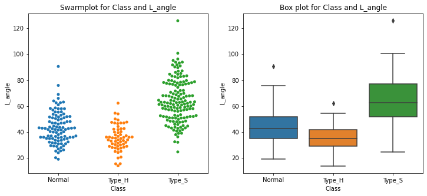

```python
fig, axes = plt.subplots(1, 2, figsize=(12,5))
sns.swarmplot (df ['Class'], df ['L_angle'], ax=axes[0]);
sns.boxplot(df['Class'], df['L_angle'], ax=axes[1])
axes[0].set_title('Swarmplot for Class and L_angle')
axes[1].set_title('Box plot for Class and L_angle')
```

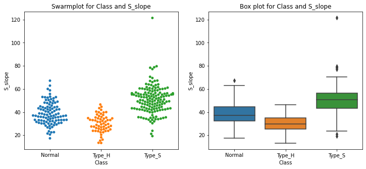

```python
fig, axes = plt.subplots(1, 2, figsize=(12,5))
sns.swarmplot (df ['Class'], df ['S_slope'], ax=axes[0]);
sns.boxplot(df['Class'], df['S_slope'], ax=axes[1])
axes[0].set_title('Swarmplot for Class and S_slope')
axes[1].set_title('Box plot for Class and S_slope')
```

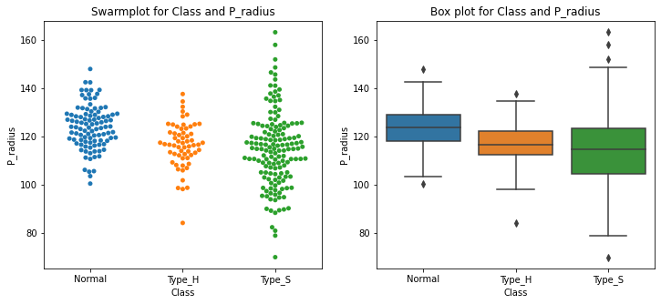

```python
fig, axes = plt.subplots(1, 2, figsize=(12,5))
sns.swarmplot (df ['Class'], df ['P_radius'], ax=axes[0]);
sns.boxplot(df['Class'], df['P_radius'], ax=axes[1])
axes[0].set_title('Swarmplot for Class and P_radius')
axes[1].set_title('Box plot for Class and P_radius')
```

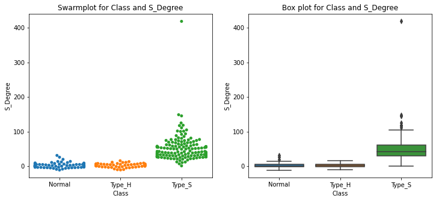

```python
fig, axes = plt.subplots(1, 2, figsize=(12,5))
sns.swarmplot (df ['Class'], df ['S_Degree'], ax=axes[0]);
sns.boxplot(df['Class'], df['S_Degree'], ax=axes[1])
axes[0].set_title('Swarmplot for Class and S_Degree')
axes[1].set_title('Box plot for Class and S_Degree')
```

#### Now we can see the relation of all the features together with

## Multivariate Analysis

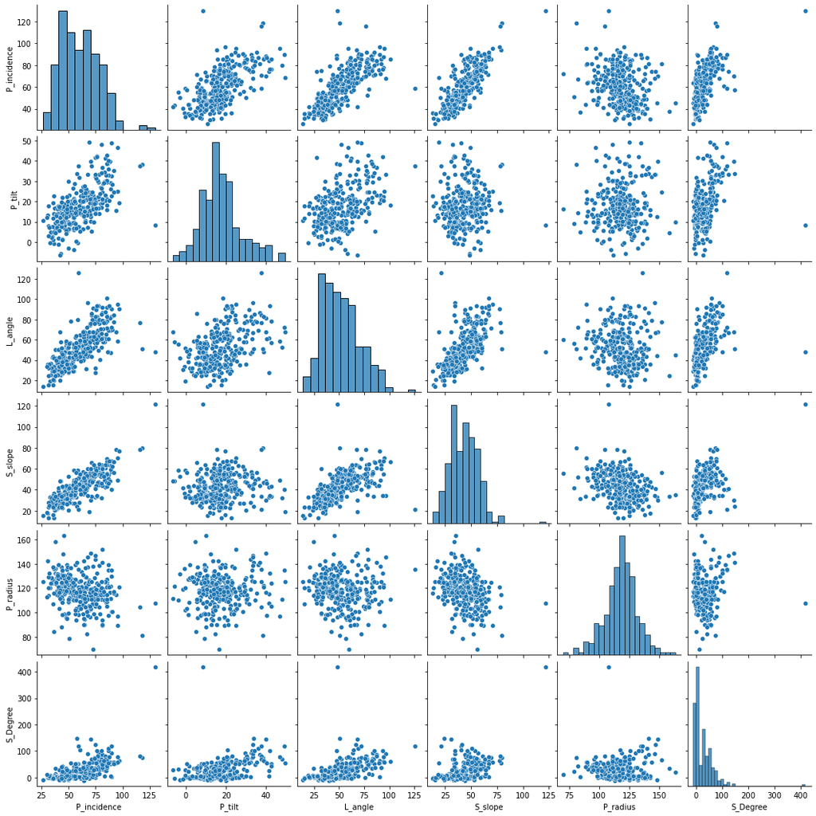

```python
sns.pairplot(df);
```

#### P_incidence has positive linear relation with most of the variables, except P_radius.

#### P_tilt shows some positive relation with P_incidence and L_angle

#### L_angle has positive relation with most of the features, except P_radius

#### S_slope has positive relation with P_incidence, L_angle, and S_degree

#### P_radius shows weak relation with most of the features.

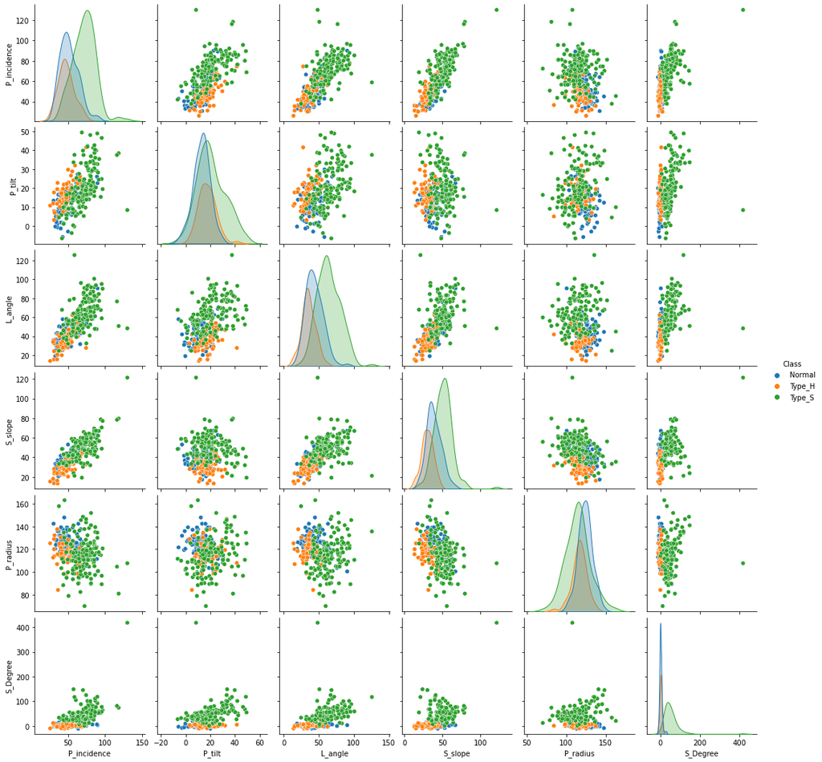

```python
sns.pairplot(df,hue='Class')
```

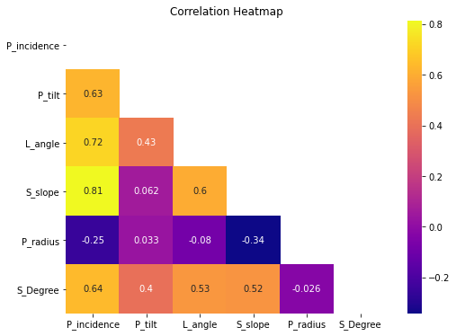

```python
plt.figure(figsize= (8,6))
mask = np.triu(np.ones_like(df.corr()))
sns.heatmap(df.corr(),mask = mask,annot=True,cmap = 'plasma')
plt.title('Correlation Heatmap')
plt.show()
```

#### Correlation between s_degree and p_incidence have high correlation.

#### S_degree and p_radius has negative correlation

# 4. Data Pre-processing

```python
from sklearn import preprocessing
from sklearn.preprocessing import LabelEncoder
```

```python
le=LabelEncoder()
df['Class']=le.fit_transform(df['Class'])
df['Class'].value_counts()
```

```
2    150
0    100
1     60
Name: Class, dtype: int64
```

```python
df['Class']=df['Class'].astype('category')
```

```python
X=df.drop(columns='Class')
y=df['Class']
```

```python
X.describe().transpose()
```

|  | count | mean | std | min | 25% | 50% | 75% | max |
| --- | --- | --- | --- | --- | --- | --- | --- | --- |
| P_incidence | 310.0 | 60.496653 | 17.236520 | 26.147921 | 46.430294 | 58.691038 | 72.877696 | 129.834041 |
| P_tilt | 310.0 | 17.542822 | 10.008330 | -6.554948 | 10.667069 | 16.357689 | 22.120395 | 49.431864 |
| L_angle | 310.0 | 51.930930 | 18.554064 | 14.000000 | 37.000000 | 49.562398 | 63.000000 | 125.742385 |
| S_slope | 310.0 | 42.953831 | 13.423102 | 13.366931 | 33.347122 | 42.404912 | 52.695888 | 121.429566 |
| P_radius | 310.0 | 117.920655 | 13.317377 | 70.082575 | 110.709196 | 118.268178 | 125.467674 | 163.071041 |
| S_Degree | 310.0 | 26.296694 | 37.559027 | -11.058179 | 1.603727 | 11.767934 | 41.287352 | 418.543082 |

```python
from scipy.stats import zscore
X_Scaled=X.apply(zscore)
```

```python
X_Scaled.describe().transpose()
```

|  | count | mean | std | min | 25% | 50% | 75% | max |
| --- | --- | --- | --- | --- | --- | --- | --- | --- |
| P_incidence | 310.0 | 8.702716e-17 | 1.001617 | -1.996010 | -0.817398 | -0.104925 | 0.719464 | 4.029206 |
| P_tilt | 310.0 | 2.326096e-16 | 1.001617 | -2.411664 | -0.688114 | -0.118606 | 0.458116 | 3.191402 |
| L_angle | 310.0 | 1.980495e-16 | 1.001617 | -2.047652 | -0.806027 | -0.127862 | 0.597549 | 3.984615 |
| S_slope | 310.0 | 5.121351e-17 | 1.001617 | -2.207741 | -0.716842 | -0.040960 | 0.726941 | 5.855771 |
| P_radius | 310.0 | -6.274551e-16 | 1.001617 | -3.597963 | -0.542383 | 0.026138 | 0.567621 | 3.395818 |
| S_Degree | 310.0 | -8.156558e-17 | 1.001617 | -0.996172 | -0.658507 | -0.387450 | 0.399768 | 10.460350 |

### Performing Train Test Split

```python
X_train, X_test, y_train, y_test = train_test_split(X, y, test_size=0.30, random_state=10)
```

```python
KNN = KNeighborsClassifier(n_neighbors= 5 , metric = 'euclidean' )
```

```python
KNN = KNeighborsClassifier(n_neighbors= 5 , metric = 'euclidean' )
KNN.fit(X_train, y_train)
predicted_labels = KNN.predict(X_test)
print('Accuracy of Training data:',KNN.score(X_train, y_train) )
print('Accuracy of Test data:',KNN.score(X_test, y_test) )
```

```
Accuracy of Training data: 0.8940092165898618
Accuracy of Test data: 0.7741935483870968
```

#### We can see that the accuracy of training data is more than accuracy of testing data, we can say it is an overfitting model. We can find the best fitting K value

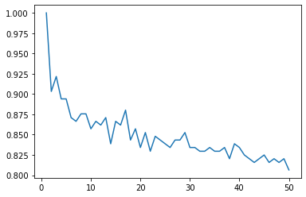

```python
train_score=[]
test_score=[]
for k in range(1,51):
    KNN = KNeighborsClassifier(n_neighbors= k , metric = 'euclidean' )
    KNN.fit(X_train, y_train)
    train_score.append(KNN.score(X_train, y_train))
    test_score.append(KNN.score(X_test, y_test))

plt.plot(range(1,51),train_score)
plt.show()
```

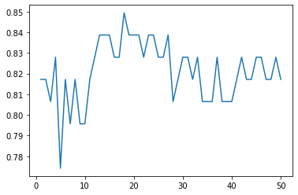

```python
plt.plot(range(1,51),test_score)
plt.show()
```

### We can see a peak near 20. We should find the optimum value of K, which should be an odd number below 20

```python
neighbors = np.arange(1,20,2)
neighbors
```

```
array([ 1,  3,  5,  7,  9, 11, 13, 15, 17, 19])
```

#### We have created a list of odd numbers till 20, we will test this list for optimal K value.

```python
from sklearn.metrics import accuracy_score
from sklearn.metrics import recall_score

ac_scores = []

for k in neighbors:
    knn = KNeighborsClassifier(n_neighbors=k)
    knn.fit(X_train, y_train)
    y_pred = knn.predict(X_test)

    scores = accuracy_score(y_test, y_pred)
    ac_scores.append(scores)

MSE = [1 - x for x in ac_scores]

optimal_k = neighbors[MSE.index(min(MSE))]
print("The optimal number of neighbors is %d" % optimal_k)
```

```
The optimal number of neighbors is 13
```

#### We can see that the best K value turns out to be 13. We should build a model using K as 13 now.

```python
KNN = KNeighborsClassifier(n_neighbors= 13 , metric = 'euclidean' )
KNN.fit(X_train, y_train)
predicted_labels = KNN.predict(X_test)
print('Accuracy of Training data:',KNN.score(X_train, y_train) )
print('Accuracy of Test data:',KNN.score(X_test, y_test) )
```

```
Accuracy of Training data: 0.8709677419354839
Accuracy of Test data: 0.8387096774193549
```

```python
from sklearn.metrics import classification_report
print("classification  Matrix:\n",classification_report(y_test,predicted_labels))
```

```
classification  Matrix:
               precision    recall  f1-score   support

           0       0.79      0.68      0.73        28
           1       0.60      0.83      0.70        18
           2       1.00      0.94      0.97        47

    accuracy                           0.84        93
   macro avg       0.80      0.82      0.80        93
weighted avg       0.86      0.84      0.84        93
```

# Conclusion:

#### Class is siginficantly affected by all the variables.

#### K value of 13, is best for model.

#### KNN model, with K=13, returned balanced train and test outuput. And Recall and precision values were also good.

#### The data was comparatively clean, with few outliers and almost balanced distribution in most.

# * PART 2 *

```python
import pandas as pd
import numpy as np
import matplotlib.pyplot as plt
%matplotlib inline
import seaborn as sns
import warnings
warnings.filterwarnings('ignore')
from scipy.stats import zscore


from sklearn.model_selection import train_test_split
from sklearn.neighbors import KNeighborsClassifier
from sklearn import preprocessing
from sklearn.preprocessing import LabelEncoder
from sklearn.metrics import accuracy_score
from sklearn.metrics import recall_score
from sklearn.metrics import classification_report
```

## 1. Import and Wareshouse Data

```python
data  = pd.read_csv('Part2 - Data1.csv')
data2 = pd.read_csv('Part2 -Data2.csv')
```

```python
data.head()
```

|  | ID | Age | CustomerSince | HighestSpend | ZipCode | HiddenScore | MonthlyAverageSpend | Level |
| --- | --- | --- | --- | --- | --- | --- | --- | --- |
| 0 | 1 | 25 | 1 | 49 | 91107 | 4 | 1.6 | 1 |
| 1 | 2 | 45 | 19 | 34 | 90089 | 3 | 1.5 | 1 |
| 2 | 3 | 39 | 15 | 11 | 94720 | 1 | 1.0 | 1 |
| 3 | 4 | 35 | 9 | 100 | 94112 | 1 | 2.7 | 2 |
| 4 | 5 | 35 | 8 | 45 | 91330 | 4 | 1.0 | 2 |

```python
data.shape
```

```
(5000, 8)
```

#### Data 1 has 5000 rows, and 8 columns.

### Analysing Data 2

```python
data2.head()
```

|  | ID | Mortgage | Security | FixedDepositAccount | InternetBanking | CreditCard | LoanOnCard |
| --- | --- | --- | --- | --- | --- | --- | --- |
| 0 | 1 | 0 | 1 | 0 | 0 | 0 | NaN |
| 1 | 2 | 0 | 1 | 0 | 0 | 0 | NaN |
| 2 | 3 | 0 | 0 | 0 | 0 | 0 | NaN |
| 3 | 4 | 0 | 0 | 0 | 0 | 0 | NaN |
| 4 | 5 | 0 | 0 | 0 | 0 | 1 | NaN |

```python
data2.shape
```

```
(5000, 7)
```

#### data 2 has 5000 rows, and 7 columns. One column less than data 1

```python
df = pd.merge(data,data2,how='inner',on='ID')
```

## 2. Data Cleansing

```python
df.head()
```

|  | ID | Age | CustomerSince | HighestSpend | ZipCode | HiddenScore | MonthlyAverageSpend | Level | Mortgage | Security | FixedDepositAccount | InternetBanking | CreditCard | LoanOnCard |
| --- | --- | --- | --- | --- | --- | --- | --- | --- | --- | --- | --- | --- | --- | --- |
| 0 | 1 | 25 | 1 | 49 | 91107 | 4 | 1.6 | 1 | 0 | 1 | 0 | 0 | 0 | NaN |
| 1 | 2 | 45 | 19 | 34 | 90089 | 3 | 1.5 | 1 | 0 | 1 | 0 | 0 | 0 | NaN |
| 2 | 3 | 39 | 15 | 11 | 94720 | 1 | 1.0 | 1 | 0 | 0 | 0 | 0 | 0 | NaN |
| 3 | 4 | 35 | 9 | 100 | 94112 | 1 | 2.7 | 2 | 0 | 0 | 0 | 0 | 0 | NaN |
| 4 | 5 | 35 | 8 | 45 | 91330 | 4 | 1.0 | 2 | 0 | 0 | 0 | 0 | 1 | NaN |

```python
df.shape
```

```
(5000, 14)
```

```python
df.dtypes
```

```
ID                       int64
Age                      int64
CustomerSince            int64
HighestSpend             int64
ZipCode                  int64
HiddenScore              int64
MonthlyAverageSpend    float64
Level                    int64
Mortgage                 int64
Security                 int64
FixedDepositAccount      int64
InternetBanking          int64
CreditCard               int64
LoanOnCard             float64
dtype: object
```

### ID can be dropped as we won't need that in model building.

### HiddenScore, ZipCode, Level, Security, FixedDepositAccount, InternetBanking, CreditCard, LoanOnCard should be Categorical features, and should be changed.

```python
df.drop('ID',axis=1,inplace=True)
```

```python
changetype =['HiddenScore','Level','Security','FixedDepositAccount', 'InternetBanking', 'CreditCard', 'LoanOnCard']
for i in changetype:
    df[i]=df[i].astype('category')
```

#### All the categorical columns are now of the desired (category) data type.

```python
df.isnull().sum()
```

```
Age                     0
CustomerSince           0
HighestSpend            0
ZipCode                 0
HiddenScore             0
MonthlyAverageSpend     0
Level                   0
Mortgage                0
Security                0
FixedDepositAccount     0
InternetBanking         0
CreditCard              0
LoanOnCard             20
dtype: int64
```

#### There are 20 Null values in 'LoanOnCard' column

#### We can drop these values as they are just 20, out of 5000 that is not even 0.5%, and dropping them won't make a significant change.

```python
df.dropna(axis=0,inplace=True)
```

```python
df.isnull().sum()
```

```
Age                    0
CustomerSince          0
HighestSpend           0
ZipCode                0
HiddenScore            0
MonthlyAverageSpend    0
Level                  0
Mortgage               0
Security               0
FixedDepositAccount    0
InternetBanking        0
CreditCard             0
LoanOnCard             0
dtype: int64
```

#### We don't have any null values in the Data frame.

## 3. Data analysis and visualisation

```python
df.describe().T
```

|  | count | mean | std | min | 25% | 50% | 75% | max |
| --- | --- | --- | --- | --- | --- | --- | --- | --- |
| Age | 4980.0 | 45.352610 | 11.464212 | 23.0 | 35.0 | 45.0 | 55.000 | 67.0 |
| CustomerSince | 4980.0 | 20.117671 | 11.468716 | -3.0 | 10.0 | 20.0 | 30.000 | 43.0 |
| HighestSpend | 4980.0 | 73.852410 | 46.070090 | 8.0 | 39.0 | 64.0 | 98.000 | 224.0 |
| ZipCode | 4980.0 | 93152.420482 | 2123.660073 | 9307.0 | 91911.0 | 93407.0 | 94608.000 | 96651.0 |
| MonthlyAverageSpend | 4980.0 | 1.939536 | 1.750006 | 0.0 | 0.7 | 1.5 | 2.525 | 10.0 |
| Mortgage | 4980.0 | 56.589759 | 101.836758 | 0.0 | 0.0 | 0.0 | 101.000 | 635.0 |

#### Age: Mean and Median are same, with evenly spread data. We shall see a normal distribution curve.

#### CustomerSince: Mean and Median are same, negative data can be seen. we shall see a normal distribution.

#### Highest Spend: Mean is greater than Median, we shall see a positive skewed curve.

#### MonthlyAverageSpend: Unit of this feature is masked, but we can see Mean is greater than median, so we shall see positive skewed curve.

#### Mortgage: There are huge fluctuations in Mortgage, as we can see 0 till 50% of the data, and spike in 75 and Max

```python
df.Mortgage.value_counts()
```

```
0      3447
98       17
91       16
83       16
89       16
       ...
541       1
509       1
505       1
485       1
577       1
Name: Mortgage, Length: 347, dtype: int64
```

#### 3447, out of 4980, are 0. This column will be highly affected by outliers.

## Univariate Analysis

```python
df.columns
```

```
Index(['Age', 'CustomerSince', 'HighestSpend', 'ZipCode', 'HiddenScore',
       'MonthlyAverageSpend', 'Level', 'Mortgage', 'Security',
       'FixedDepositAccount', 'InternetBanking', 'CreditCard', 'LoanOnCard'],
      dtype='object')
```

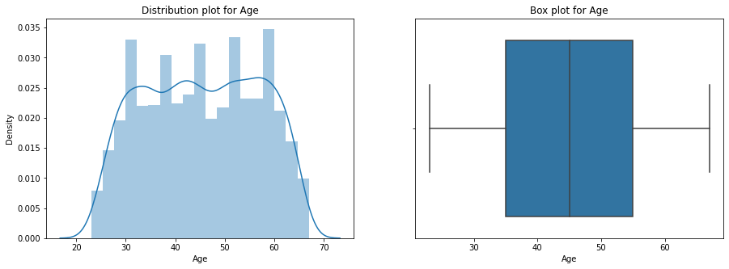

```
 Total Number of outliers in Age: 0
```

```python
fig, axes = plt.subplots(1, 2, figsize=(15,5))
sns.boxplot(x = 'Age', data=df , ax=axes[1])
sns.distplot(df['Age'],  ax=axes[0])
axes[0].set_title('Distribution plot for Age')
axes[1].set_title('Box plot for Age')
plt.show()


q25= np.percentile(df['Age'],25)
q75= np.percentile(df['Age'],75)
iqr= q75-q25
threshold= iqr*1.5
lower = q25-threshold
upper = q75+threshold
outliers = [i for i in df['Age'] if i < lower or i > upper]
print ('{} Total Number of outliers in Age: {}'.format('\033[1m',len(outliers)))
```

#### We can see a multimodal distribution of Age, with no outliers.

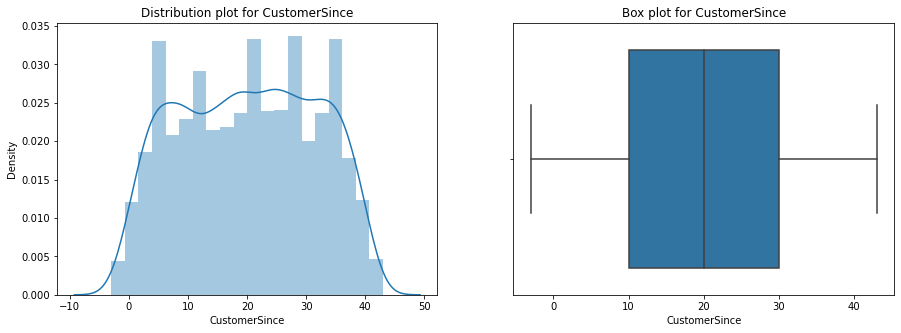

```
 Total Number of outliers in CustomerSince: 0
```

```python
fig, axes = plt.subplots(1, 2, figsize=(15,5))
sns.boxplot(x = 'CustomerSince', data=df , ax=axes[1])
sns.distplot(df['CustomerSince'],  ax=axes[0])
axes[0].set_title('Distribution plot for CustomerSince')
axes[1].set_title('Box plot for CustomerSince')
plt.show()


q25= np.percentile(df['CustomerSince'],25)
q75= np.percentile(df['CustomerSince'],75)
iqr= q75-q25
threshold= iqr*1.5
lower = q25-threshold
upper = q75+threshold
outliers = [i for i in df['CustomerSince'] if i < lower or i > upper]
print ('{} Total Number of outliers in CustomerSince: {}'.format('\033[1m',len(outliers)))
```

#### We can see multimodal distribution for Customer Since column, with most of the values lying between 5 to 35. Normality can be seen in the curve

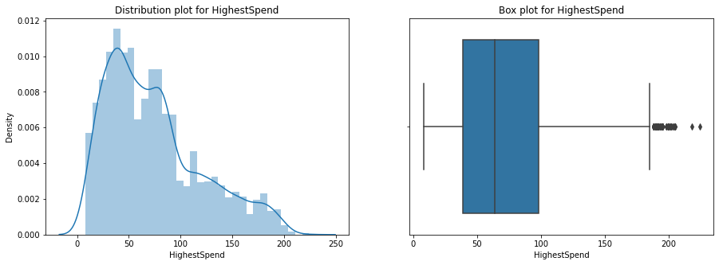

```
 Total Number of outliers in HighestSpend: 96
```

```python
fig, axes = plt.subplots(1, 2, figsize=(15,5))
sns.boxplot(x = 'HighestSpend', data=df , ax=axes[1])
sns.distplot(df['HighestSpend'],  ax=axes[0])
axes[0].set_title('Distribution plot for HighestSpend')
axes[1].set_title('Box plot for HighestSpend')
plt.show()


q25= np.percentile(df['HighestSpend'],25)
q75= np.percentile(df['HighestSpend'],75)
iqr= q75-q25
threshold= iqr*1.5
lower = q25-threshold
upper = q75+threshold
outliers = [i for i in df['HighestSpend'] if i < lower or i > upper]
print ('{} Total Number of outliers in HighestSpend: {}'.format('\033[1m',len(outliers)))
```

#### There are 96 outliers.

#### Positive skewness can be observed.

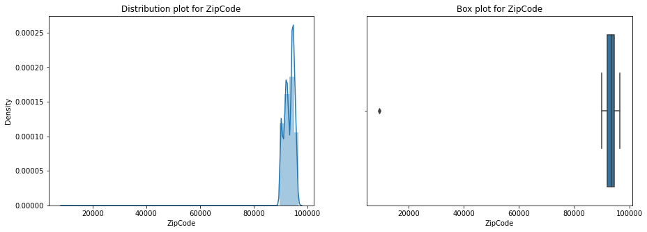

```
 Total Number of outliers in ZipCode: 1
```

```python
fig, axes = plt.subplots(1, 2, figsize=(15,5))
sns.boxplot(x = 'ZipCode', data=df , ax=axes[1])
sns.distplot(df['ZipCode'],  ax=axes[0])
axes[0].set_title('Distribution plot for ZipCode')
axes[1].set_title('Box plot for ZipCode')
plt.show()


q25= np.percentile(df['ZipCode'],25)
q75= np.percentile(df['ZipCode'],75)
iqr= q75-q25
threshold= iqr*1.5
lower = q25-threshold
upper = q75+threshold
outliers = [i for i in df['ZipCode'] if i < lower or i > upper]
print ('{} Total Number of outliers in ZipCode: {}'.format('\033[1m',len(outliers)))
```

```python
df.ZipCode.value_counts()
```

```
94720    167
94305    125
95616    116
90095     71
93106     57
        ...
96145      1
94970      1
94598      1
90068      1
94087      1
Name: ZipCode, Length: 467, dtype: int64
```

#### We cannot see any pattern of ZipCode as most of the values are occuring once only. a few ZipCodes have been repeated but no pattern can be seen.

```python
df.drop('ZipCode',axis=1,inplace=True)
```

#### We have dropped ZipCode as it won't serve any purpose in model building.

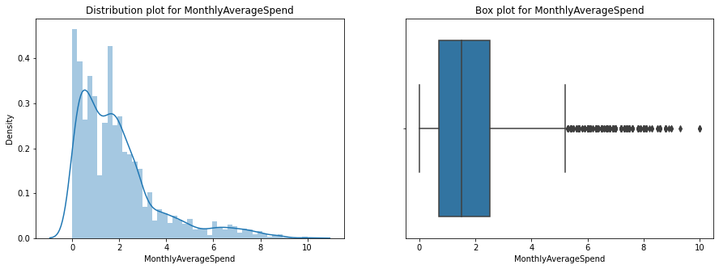

```
 Total Number of outliers in HighestSpend: 324
```

```python
fig, axes = plt.subplots(1, 2, figsize=(15,5))
sns.boxplot(x = 'MonthlyAverageSpend', data=df , ax=axes[1])
sns.distplot(df['MonthlyAverageSpend'],  ax=axes[0])
axes[0].set_title('Distribution plot for MonthlyAverageSpend')
axes[1].set_title('Box plot for MonthlyAverageSpend')
plt.show()


q25= np.percentile(df['MonthlyAverageSpend'],25)
q75= np.percentile(df['MonthlyAverageSpend'],75)
iqr= q75-q25
threshold= iqr*1.5
lower = q25-threshold
upper = q75+threshold
outliers = [i for i in df['MonthlyAverageSpend'] if i < lower or i > upper]
print ('{} Total Number of outliers in HighestSpend: {}'.format('\033[1m',len(outliers)))
```

#### There are 324 outliers. We can say it is a bi-modal distribution. We can see a right skewed curve.

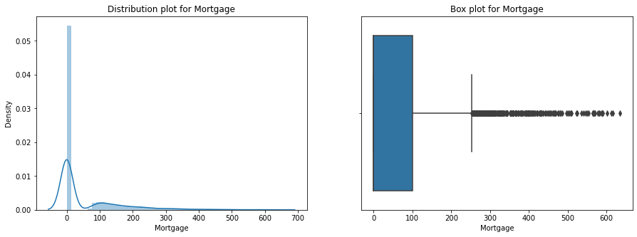

```
 Total Number of outliers in Mortgage: 291
```

```python
fig, axes = plt.subplots(1, 2, figsize=(15,5))
sns.boxplot(x = 'Mortgage', data=df , ax=axes[1])
sns.distplot(df['Mortgage'],  ax=axes[0])
axes[0].set_title('Distribution plot for Mortgage')
axes[1].set_title('Box plot for Mortgage')
plt.show()


q25= np.percentile(df['Mortgage'],25)
q75= np.percentile(df['Mortgage'],75)
iqr= q75-q25
threshold= iqr*1.5
lower = q25-threshold
upper = q75+threshold
outliers = [i for i in df['Mortgage'] if i < lower or i > upper]
print ('{} Total Number of outliers in Mortgage: {}'.format('\033[1m',len(outliers)))
```

```python
df.Mortgage.value_counts()
```

```
0      3447
98       17
91       16
83       16
89       16
       ...
541       1
509       1
505       1
485       1
577       1
Name: Mortgage, Length: 347, dtype: int64
```

#### We can see most of the values in Mortgage is 0.

#### It shows most of the customers doesn't have any mortgage.

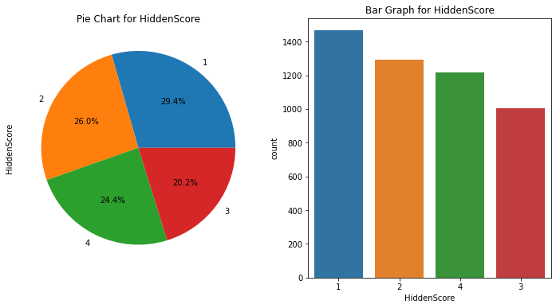

```python
f,axes=plt.subplots(1,2,figsize=(12,6))
df['HiddenScore'].value_counts().plot.pie(autopct='%1.1f%%',ax=axes[0])
sns.countplot('HiddenScore',data=df,ax=axes[1],order=[1,2,4,3])
axes[0].set_title('Pie Chart for HiddenScore')
axes[1].set_title('Bar Graph for HiddenScore')
plt.show()
```

```python
df.dtypes
```

```
Age                       int64
CustomerSince             int64
HighestSpend              int64
HiddenScore            category
MonthlyAverageSpend     float64
Level                  category
Mortgage                  int64
Security               category
FixedDepositAccount    category
InternetBanking        category
CreditCard             category
LoanOnCard             category
dtype: object
```

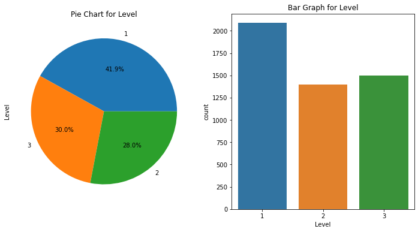

```python
f,axes=plt.subplots(1,2,figsize=(12,6))
df['Level'].value_counts().plot.pie(autopct='%1.1f%%',ax=axes[0])
sns.countplot('Level',data=df,ax=axes[1],order=[1,2,3])
axes[0].set_title('Pie Chart for Level')
axes[1].set_title('Bar Graph for Level')
plt.show()
```

#### Level 1 is higher than the others. Level 2 and Level 3 are almost same.

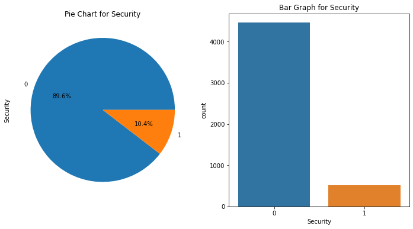

```python
f,axes=plt.subplots(1,2,figsize=(12,6))
df['Security'].value_counts().plot.pie(autopct='%1.1f%%',ax=axes[0])
sns.countplot('Security',data=df,ax=axes[1],order=[0,1])
axes[0].set_title('Pie Chart for Security')
axes[1].set_title('Bar Graph for Security')
plt.show()
```

#### Almost 90% of the people do not have Security

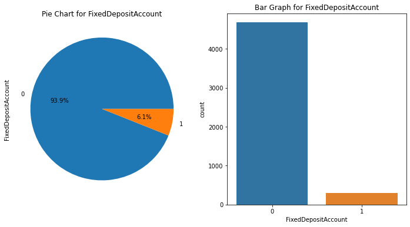

```python
f,axes=plt.subplots(1,2,figsize=(12,6))
df['FixedDepositAccount'].value_counts().plot.pie(autopct='%1.1f%%',ax=axes[0])
sns.countplot('FixedDepositAccount',data=df,ax=axes[1],order=[0,1])
axes[0].set_title('Pie Chart for FixedDepositAccount')
axes[1].set_title('Bar Graph for FixedDepositAccount')
plt.show()
```

#### Almost 94% of the people do not have Fixed Deposit Account

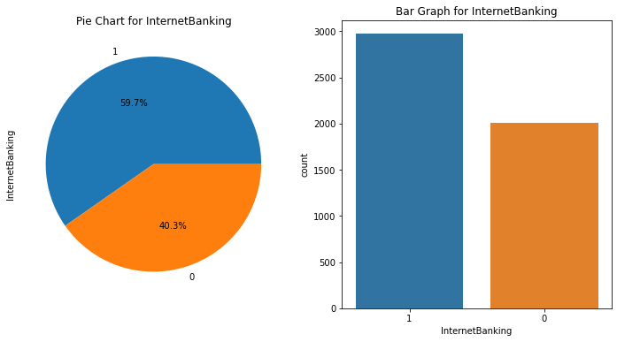

```python
f,axes=plt.subplots(1,2,figsize=(12,6))
df['InternetBanking'].value_counts().plot.pie(autopct='%1.1f%%',ax=axes[0])
sns.countplot('InternetBanking',data=df,ax=axes[1],order=[1,0])
axes[0].set_title('Pie Chart for InternetBanking')
axes[1].set_title('Bar Graph for InternetBanking')
plt.show()
```

#### 59.7% of the people use Internet banking

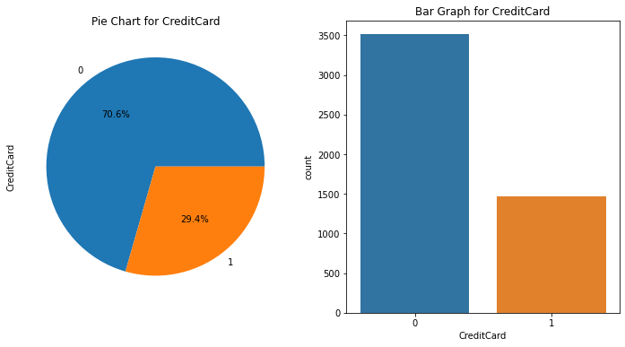

```python
f,axes=plt.subplots(1,2,figsize=(12,6))
df['CreditCard'].value_counts().plot.pie(autopct='%1.1f%%',ax=axes[0])
sns.countplot('CreditCard',data=df,ax=axes[1],order=[0,1])
axes[0].set_title('Pie Chart for CreditCard')
axes[1].set_title('Bar Graph for CreditCard')
plt.show()
```

#### 70% of the people does not have Credit Card

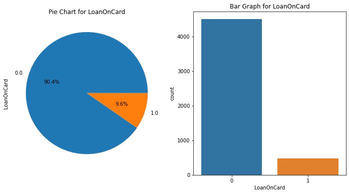

```python
f,axes=plt.subplots(1,2,figsize=(12,6))
df['LoanOnCard'].value_counts().plot.pie(autopct='%1.1f%%',ax=axes[0])
sns.countplot('LoanOnCard',data=df,ax=axes[1],order=[0,1])
axes[0].set_title('Pie Chart for LoanOnCard')
axes[1].set_title('Bar Graph for LoanOnCard')
plt.show()
```

```python
df.dtypes
```

```
Age                       int64
CustomerSince             int64
HighestSpend              int64
HiddenScore            category
MonthlyAverageSpend     float64
Level                  category
Mortgage                  int64
Security               category
FixedDepositAccount    category
InternetBanking        category
CreditCard             category
LoanOnCard             category
dtype: object
```

#### 90% of the people do not have any Loan on Card

## Bi variate Analysis

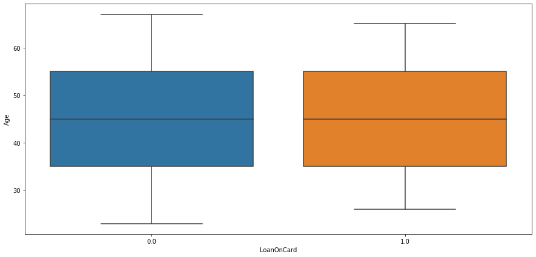

```python
# Age vs LoanOnCard

plt.figure(figsize=(15,7))
sns.boxplot(x='LoanOnCard', y='Age', data= df)
plt.show()
```